# RNAed_Report

ab

January 16, 2019

RNAediting landscape in FANTOM6 transcriptome profiling

1. Data analysis

As knockdown samples were present only for two types of cells (Feeder-free iPSC and Dermal fibroblasts) I decided to check variables inside a control group beforehand. Firstly, I looked at Editing Fraction(EF) distribution in control group across all cell types.

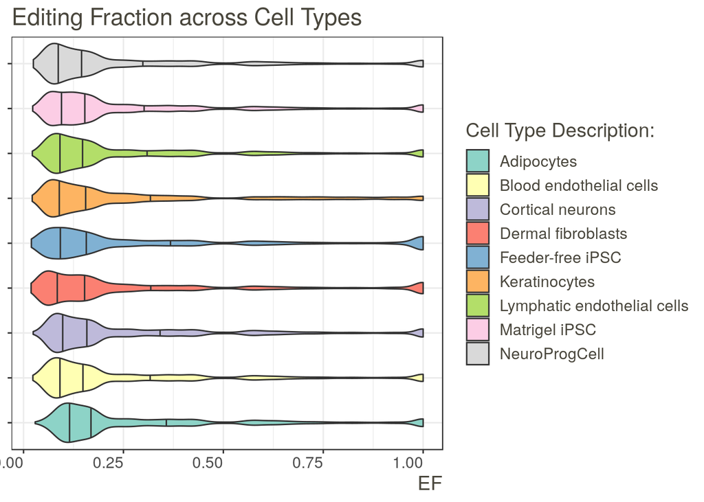

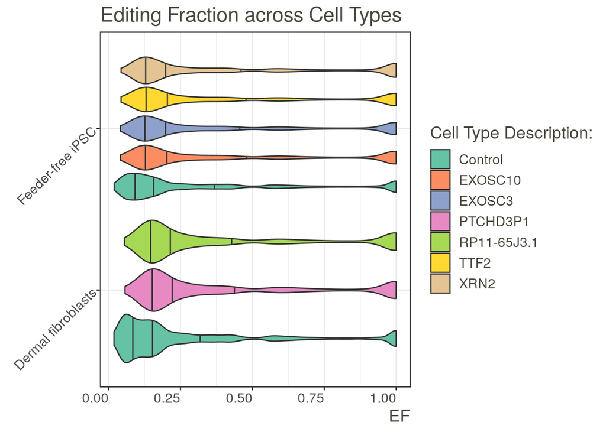

The similar two-peaked pattern were present in knockdown-control pairs as well. Further, I checked distributions of sequencing depths (DP) in a similar fashion for controls and control-knockdown pairs.

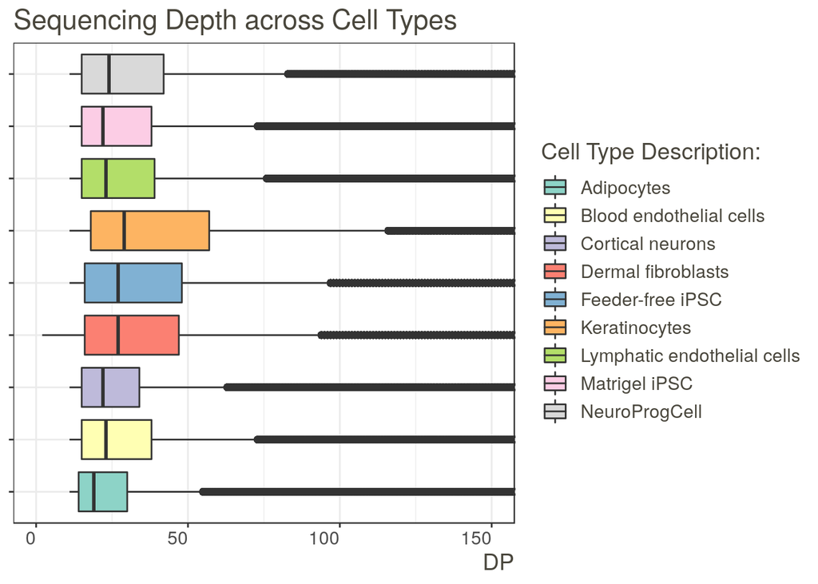

DP medians across all samples are centered around ~25 with significant number of high-order outliers. Medians of knockdowns were lower when compared to paired controls, though differed not significantly from controls of other cell types.

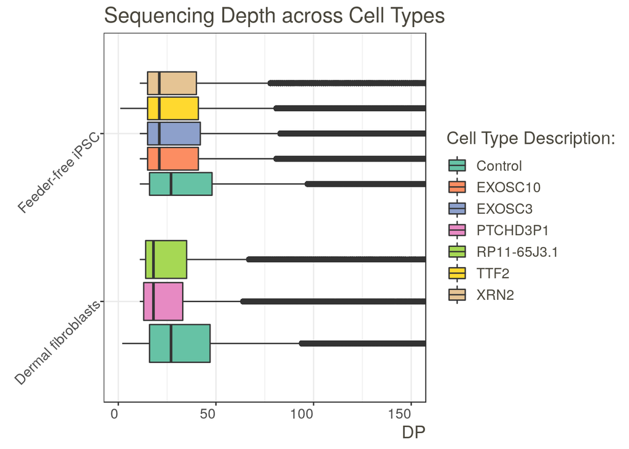

At the same time, the number of registered Editing Events varied considerably between cell types.

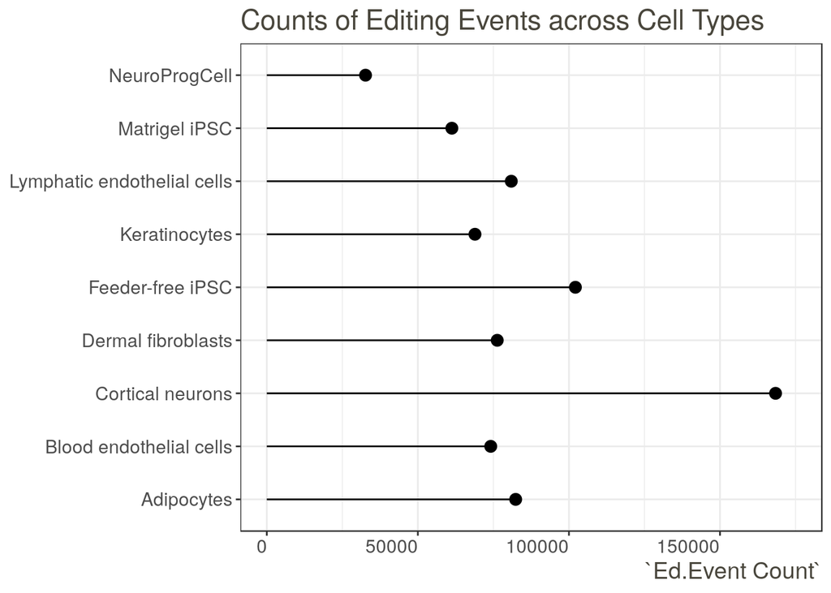

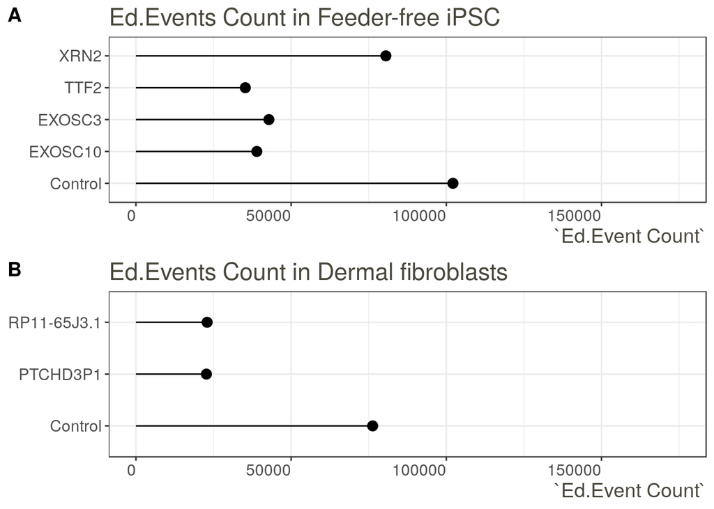

Further, I checked the localization of observed editing events across controls of different cell types. For this purpose, I downloaded table of annotated editing sites from RADAR database and intersected it with editing data from FANTOM6 resulting in 3571 annotated sites from 990248 which I had at the beginning. In general, localization of editing samples was similar across all control samples. Few nonsynonymous substitutions were observed in endothelial cells, both lymphatic and blood, and in dermal fibroblasts.

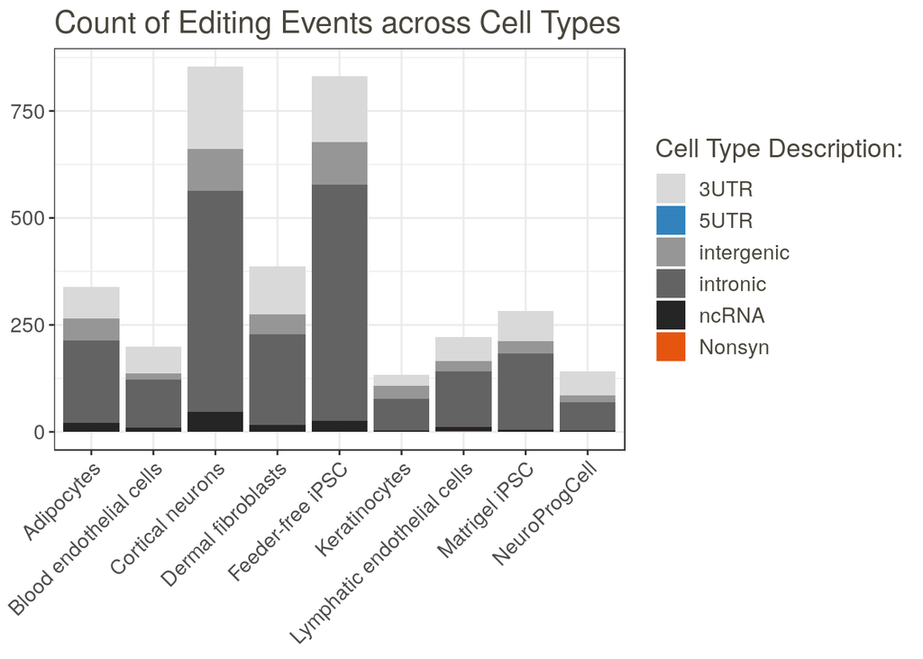

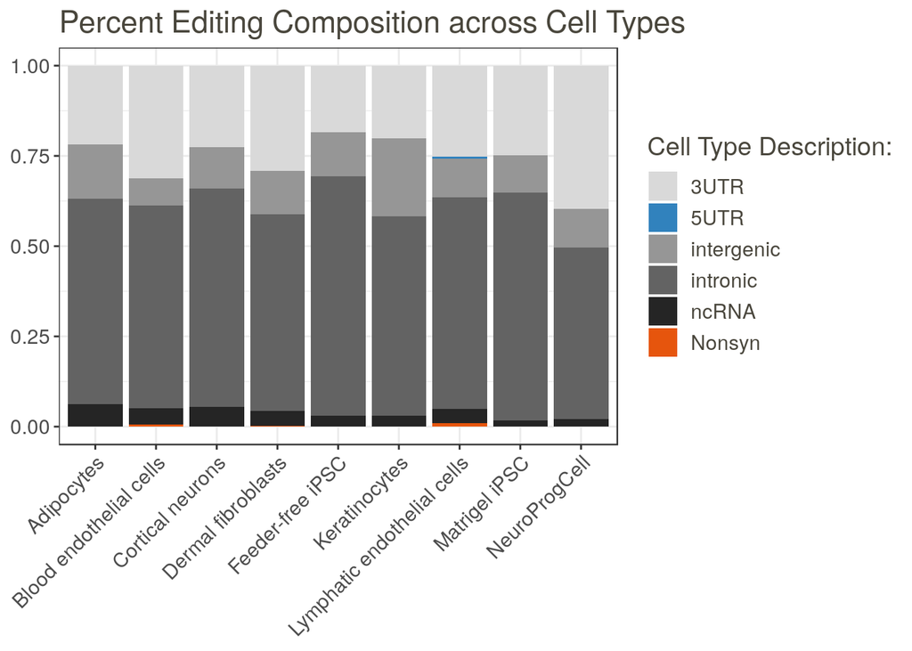

Interestingly, nonsynonymous substitutions in both endothelial cells occurred in the same placce in the same gene - ENSA. This gene encodes Alpha-endosulphine protein, a member of a highly conserved cAMP-regulated phosphoprotein family. These editing events substitute a consensus T for C and generating a new CAG splice-site inside of exon 5 of ENSA.